# Exercises 1

### Safer Split

```r
###### Safer Split

set.seed(10)
initial_wealth = 100000

weights = c(0.075, 0, 0.85, 0.025, 0.05)
holdings = weights * total_wealth
n_days = 20          #T
wealthtracker = rep(0, n_days) # Set up a placeholder to track total wealth, take a closet and put all for loop result in it

# simulated 2 week trajectory
for(today in 1:n_days) {
  return.today = resample(all_returns, 1, orig.ids=FALSE)
  holdings = holdings + holdings*return.today
  total_wealth = sum(holdings)
  wealthtracker[today] = total_wealth
}
total_wealth
```

```
## [1] 99292.65
```

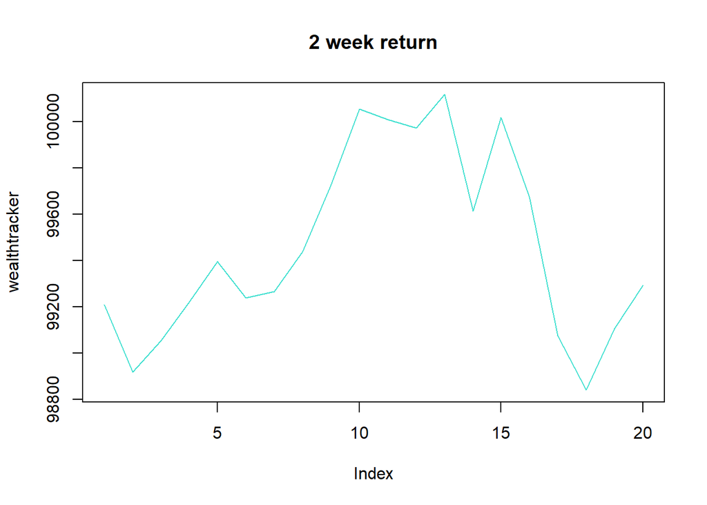

```r
plot(wealthtracker, type='l', col="#40E0D0")
title("2 week return")
```

```r
# Now simulate many different possible scenarios
initial_wealth = 100000
sim1 = foreach(i=1:6000, .combine='rbind') %do% {
  total_wealth = initial_wealth
  weights = c(0.075, 0, 0.80, 0.025, 0.10)
  holdings = weights * total_wealth
  n_days = 20
  wealthtracker = rep(0, n_days)
  for(today in 1:n_days) {
    return.today = resample(all_returns, 1, orig.ids=FALSE)
    holdings = weights * total_wealth
    holdings = holdings + holdings*return.today
    total_wealth = sum(holdings)
    wealthtracker[today] = total_wealth
  }
  wealthtracker
}

head(sim1)
```

```
##               [,1]      [,2]      [,3]      [,4]      [,5]      [,6]
## result.1  99837.99 100148.41 100112.10 100106.25 100252.20 101600.39
## result.2 100703.95 101180.05 101090.17 101363.54 101524.21 102910.03
## result.3  99752.44  99322.07  98954.62  98978.00  99405.67  99412.57
## result.4 100204.32  99995.46 100134.27 100289.92 100810.28 100590.99
## result.5 100064.94  99598.75  99742.76  99435.92  99536.86  99643.64
## result.6 100035.26  99934.03 100396.97 100491.92  99402.25  99196.81
##               [,7]      [,8]      [,9]     [,10]     [,11]     [,12]
## result.1 101497.57 101499.64 101403.91 101596.44 101727.63 102671.68
## result.2 102431.41 102564.03 102098.35 102282.78 101900.60 101967.40
## result.3  99397.61  99581.95  99876.44 101004.74 100867.86 100918.50
## result.4 100603.64 100664.71 102861.13 102973.95 102892.51 102961.34
## result.5  99610.82  99827.01  99880.14  99129.29  98641.61  98863.67
## result.6  99123.38  98972.95  98688.72  98744.65  98646.07  98602.88
##              [,13]     [,14]     [,15]     [,16]     [,17]    [,18]
## result.1 102146.70 102307.96 102005.21 102055.49 102074.88 102454.4
## result.2 102784.79 102988.92 102880.32 102732.74 102958.92 103060.0
## result.3 100954.94 101284.85 101848.65 101910.75 102040.38 102072.9
## result.4 103564.11 103075.78 103483.13 102179.85 101685.28 101262.9
## result.5  97684.76  97657.68  97544.97  97106.24  96870.07  97449.9
## result.6  99378.65  99826.28 100120.03  99975.07 100003.67 100486.3
##              [,19]     [,20]
## result.1 102347.06 102241.47
## result.2 102769.81 102774.69
## result.3 101928.22 102138.35
## result.4 101043.40 100804.96
## result.5  97380.27  97650.69
## result.6 100780.90 100632.26
```

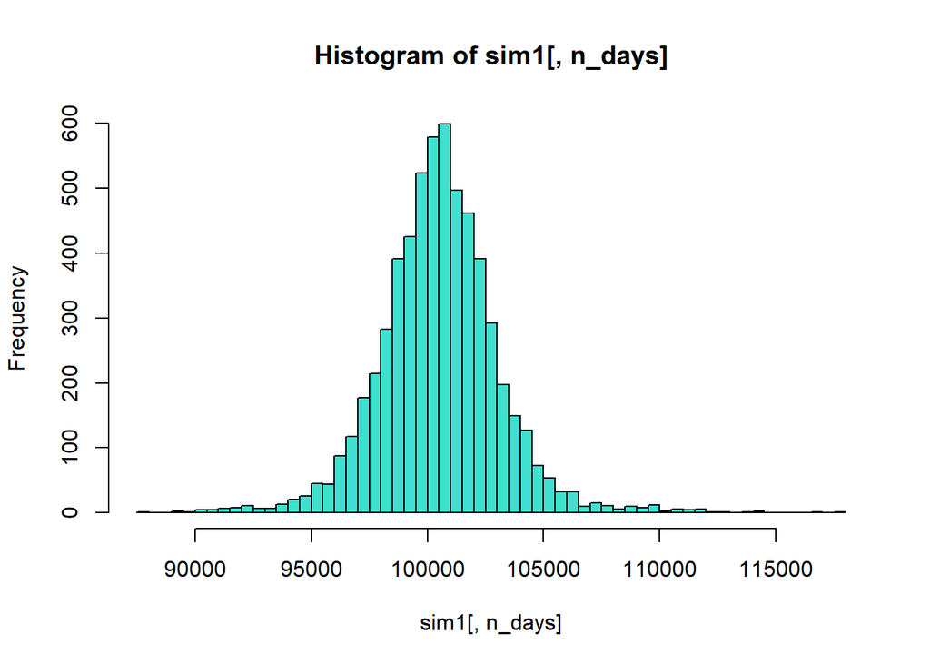

```r
hist(sim1[,n_days], 60, col="#40E0D0")
```

```r
# Profit/loss
mean(sim1[,n_days])
```

```
## [1] 100508.5
```

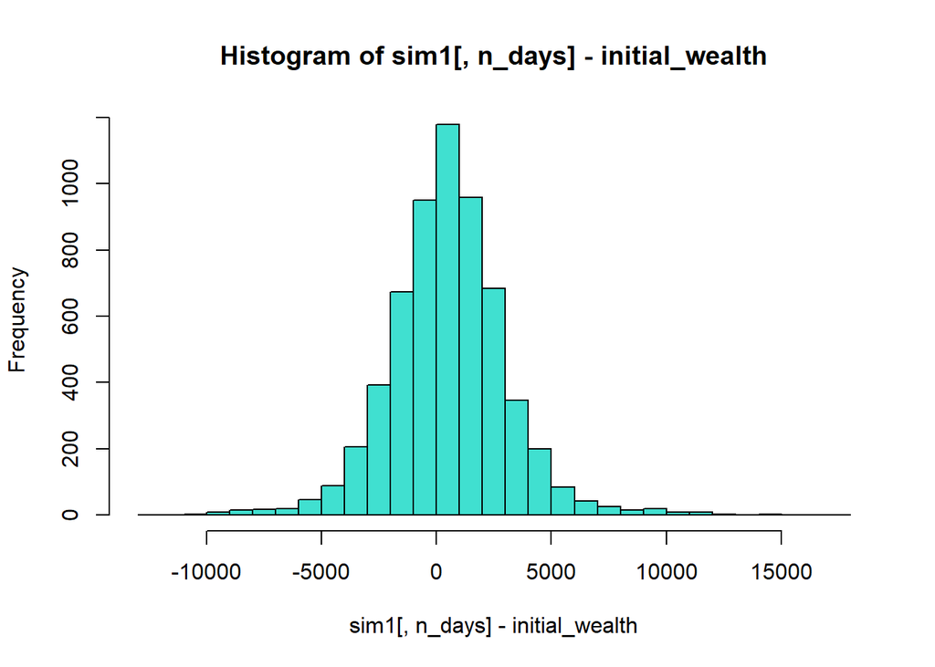

```r
hist(sim1[,n_days]- initial_wealth, breaks=30, col="#40E0D0")
```

```r
# Calculate 5% value at risk
quantile(sim1[,n_days], 0.05)
```

```
##       5%
## 96600.53
```

```r
#histogram simulated data

Loss = initial_wealth-quantile(sim1[,n_days], 0.05)
Loss
```

```
##       5%
## 3399.472
```

### High Risk Split

```r
###### High risk Split

set.seed(10)
initial_wealth = 100000

weights = c(0.1, 0.3, 0.1, 0.20, 0.3)
holdings = weights * total_wealth
n_days = 20          #T
wealthtracker = rep(0, n_days) # Set up a placeholder to track total wealth, take a closet and put all for loop result in it

# simulated 2 week trajectory
for(today in 1:n_days) {
  return.today = resample(all_returns, 1, orig.ids=FALSE)
  holdings = holdings + holdings*return.today
  total_wealth = sum(holdings)
  wealthtracker[today] = total_wealth
}
total_wealth
```

```
## [1] 99017.76
```

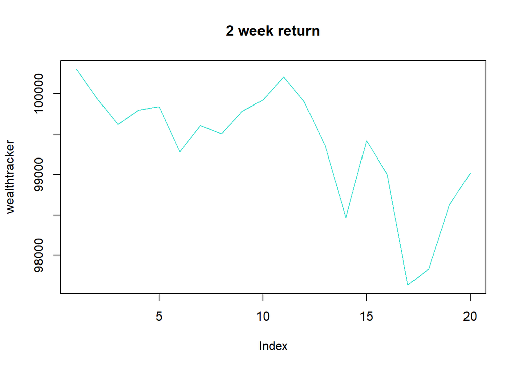

```r
plot(wealthtracker, type='l', col="#40E0D0")
title("2 week return")
```

```r
# Now simulate many different possible scenarios
initial_wealth = 100000
sim1 = foreach(i=1:6000, .combine='rbind') %do% {
  total_wealth = initial_wealth
  weights = c(0.1, 0.3, 0.1, 0.20, 0.3)
  holdings = weights * total_wealth
  n_days = 20
  wealthtracker = rep(0, n_days)
  for(today in 1:n_days) {
    return.today = resample(all_returns, 1, orig.ids=FALSE)
    holdings = weights * total_wealth
    holdings = holdings + holdings*return.today
    total_wealth = sum(holdings)
    wealthtracker[today] = total_wealth
  }
  wealthtracker
}

head(sim1)
```

```
##               [,1]      [,2]      [,3]      [,4]      [,5]      [,6]
## result.1  99800.01  99972.89  99701.55  99889.29 100491.74 102440.68
## result.2 101348.52 101699.05 101264.70 101242.28 100924.88 106882.87
## result.3  99660.55  99417.35  98466.59  97273.81  98190.69  99144.69
## result.4 100261.57  99764.98 100954.38 101350.45 102591.06 101876.83
## result.5 100149.50  98650.18  98968.55  99160.35  99069.92  98956.41
## result.6  99847.53  98935.30  99202.61  99386.69  96757.88  96461.63
##               [,7]      [,8]      [,9]     [,10]     [,11]     [,12]
## result.1 102178.54 101942.05 101617.52 101816.55 102161.30 104242.32
## result.2 106264.48 106427.47 105249.60 105396.20 104915.11 105106.58
## result.3  98801.05  99568.09 100451.11 101097.50 100841.79 100750.23
## result.4 101560.86 101896.45 106445.73 105972.67 105745.59 106279.22
## result.5  99225.62  99379.51  99498.88  98226.65  97410.48  97763.59
## result.6  96359.21  96173.59  95704.00  95781.23  95687.46  95244.08
##              [,13]     [,14]     [,15]     [,16]     [,17]     [,18]
## result.1 106343.42 106586.64 106130.36 107047.12 107024.34 108003.54
## result.2 107718.24 108033.50 108516.87 108408.84 108551.14 108905.38
## result.3 100849.70 101471.89 101927.39 102061.86 102146.14 101942.26
## result.4 107154.88 106480.30 107161.19 104299.47 103897.18 102779.40
## result.5  95630.16  95277.21  94929.19  94626.27  94213.59  95115.54
## result.6  96407.43  97291.36  97225.12  96378.73  96321.97  97092.31
##              [,19]     [,20]
## result.1 108235.36 107911.03
## result.2 108806.37 108874.03
## result.3 102067.30 101499.40
## result.4 102339.64 101399.14
## result.5  95096.49  95654.26
## result.6  97483.15  96909.61
```

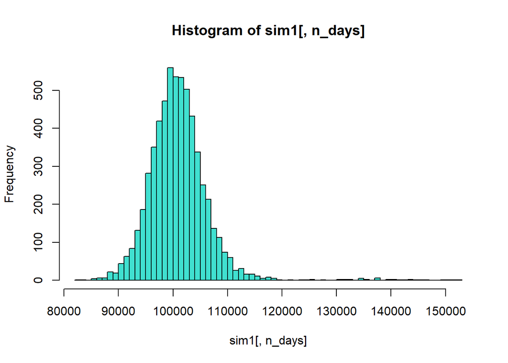

```r
hist(sim1[,n_days], 60, col="#40E0D0")
```

```r
# Profit/loss
mean(sim1[,n_days])
```

```
## [1] 100975.9
```

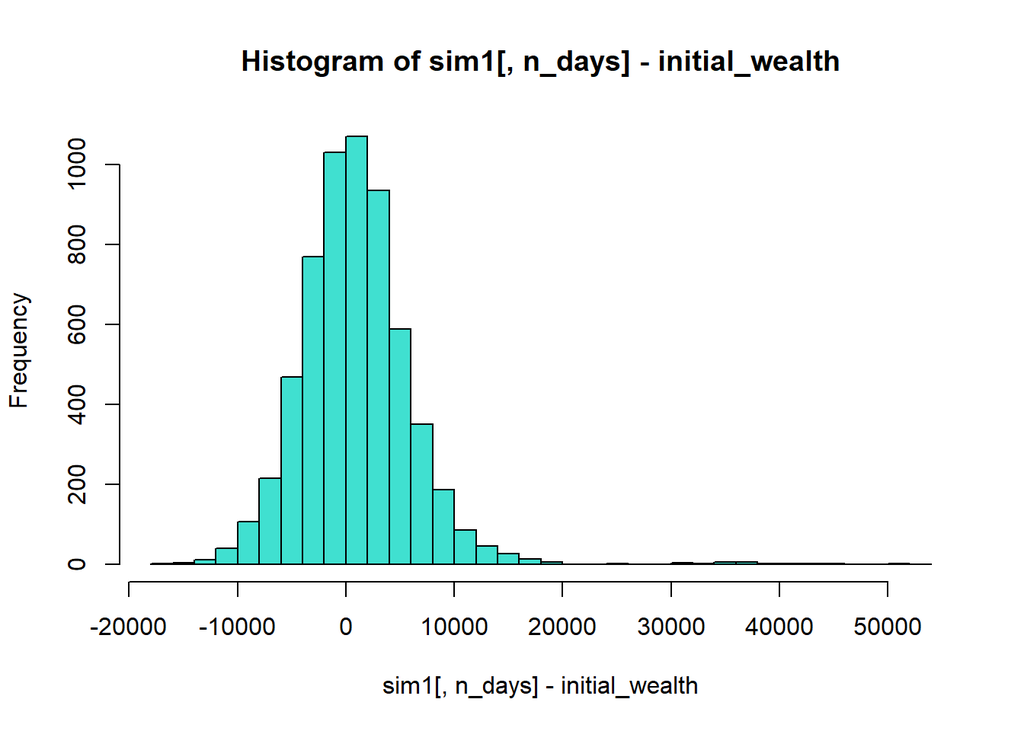

```r
hist(sim1[,n_days]- initial_wealth, breaks=30, col="#40E0D0")
```

```r
# Calculate 5% value at risk
quantile(sim1[,n_days], 0.05)
```

```
##       5%
## 93346.03
```

```r
#histogram simulated data

Loss = initial_wealth-quantile(sim1[,n_days], 0.05)
Loss
```

```
##      5%
## 6653.97
```

### Market segmentation

NutrientH20 can segregate it’s online audinece in the following clusters. The analysis for the same has been done in the codes that follow:

| Clusters | Features |
| --- | --- |
| Cluster 8 | health_nutrition, eco, outdoors, personal_fitness |
| Cluster 7 | online_gaming, college_uni, sports_playing |
| Cluster 6 | current-events, tv-film, shopping, business, art, dating, small_business |
| Cluster 5 | home_and-garden, spam, adult |
| Cluster 4 | photo_sharing, uncategorized, music, cooking, beauty, fashion |
| Cluster 3 | sports_fandom, food, family, crafts, religion, parenting, school |
| Cluster 2 | travel, politics, news, computers, automotive |

In the above clusters, cluster 8 belongs to sportsmen & fitness conscious customers which can be targeted accordingly. Cluster 7 is college going youth actively involved in online gaming and sports. Cluster 6 seems like a more mature professional audience. Cluster 5 includes the misc category. Cluster 4 seems to be covering the female followers. Cluster 3 is a more mature family audience & Cluster 2 appear to include online bloggers, active twitterati, tech savvy & politics acquainted audience.

Approach:

1. Plotted a scree plot to check best k
2. Selected one with few clusters as per business requirements.
3. Checked which feature fell into one of clusters more often, assigned the feature too the same cluster.

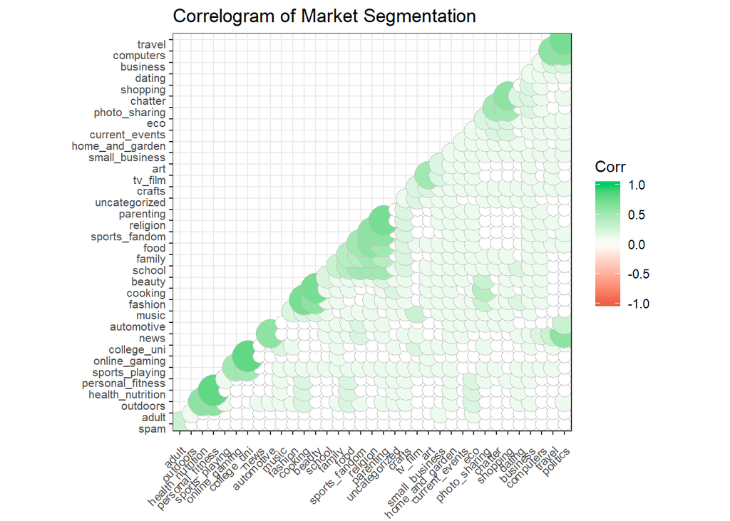

```r
library(ggplot2)
library(LICORS)  # for kmeans++
library(foreach)
library(mosaic)

socialmkt = read.csv('social_marketing.csv', header=TRUE)
socialmkt = na.omit(socialmkt)

# Correlation matrix
corr <- round(cor(socialmkt[,-1]), 1)

# Plot
ggcorrplot(corr, hc.order = TRUE,
           type = "lower",
           lab_size = 8,
           method="circle",
           colors = c("tomato2", "white", "springgreen3"),
           title="Correlogram of Market Segmentation", tl.cex=8,
           ggtheme=theme_bw)+theme(axis.text.x = element_text(angle=45, vjust=0.9))+theme(axis.text.y = element_text(angle=0, vjust=0.9))
```

From initial exploration, we saw some strong correlations between few features: health_nutrition, outdoors & personal fitness seemed to be related; online gaming, college university & sports playing seemed related too, others include: family, food, sports_fandom, religion, parenting and uncategorized; computers, travel, politics and photo sharing, chatter& shopping.

These variables had a possibility of being clustered which was later confirmed in final exercise.

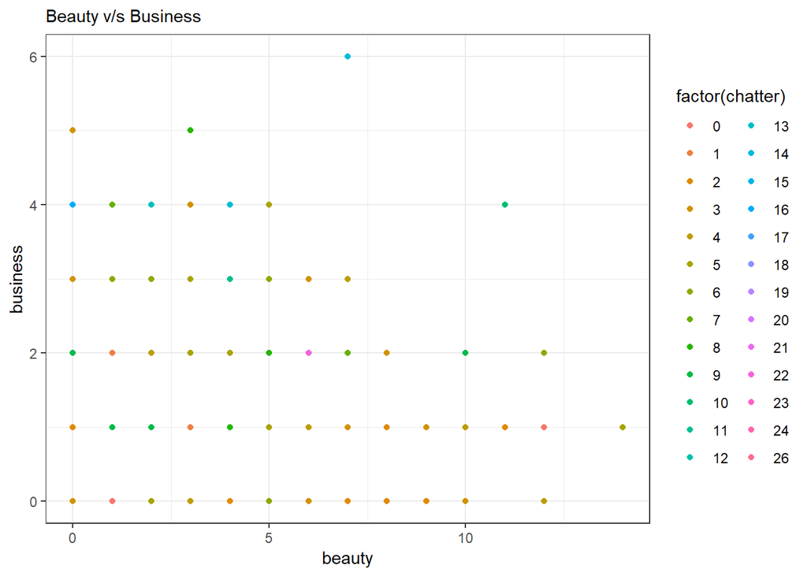

```r
qplot(beauty, business,data=socialmkt, color=factor(chatter)) +
  labs(subtitle="Beauty v/s Business")
```

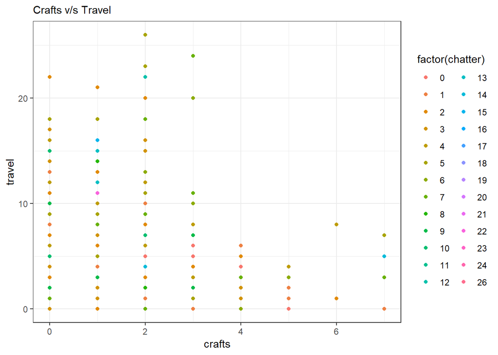

```r
qplot(crafts,travel, data=socialmkt, color=factor(chatter))+
  labs(subtitle="Crafts v/s Travel")
```

Both seem to be inversely correlated.

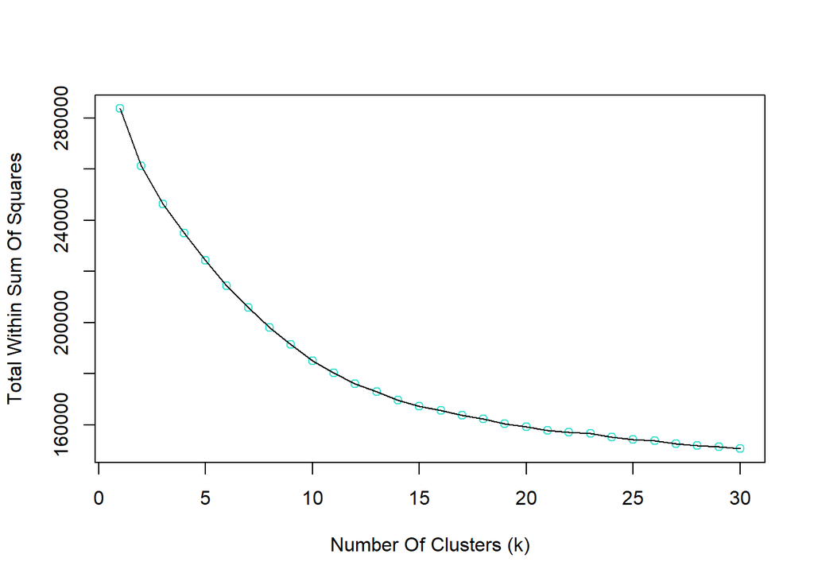

```
## integer(0)
```

```r
# Center and scale the data
X = socialmkt[,-1]
X = scale(X, center=TRUE, scale=TRUE)

# Extract the centers and scales from the rescaled data (which are named attributes)
mu = attr(X,"scaled:center")
sigma = attr(X,"scaled:scale")

####  Optimal Amount Of Clusters (k):

# Scree Plot For Determining Optimal k Clusters.

total_wsumsq <- rep(0, 30) #Initialize

for (k in 1:30){
  kmeans <- kmeans(X, centers = k, nstart = 25)

  # Scree Plot use total within cluster sum of squares

  total_wsumsq[k] <- kmeans$tot.withinss
}
## Scree Plot In Base R:

plot(x = 1:30, y = total_wsumsq , xlab = "Number Of Clusters (k)",
     ylab = "Total Within Sum Of Squares", col="#40E0D0") +
  lines(x = 1:30, y = total_wsumsq)
```

From the scree plot above, we see that the cluster distances would be minimised at about 30 centres. But marketing campaigns generally cannot cater to so scattered target audience (the solution above was overfitting) due to excessive campaign cost. Tried 6-10 centres in K means clustering beyond this point.

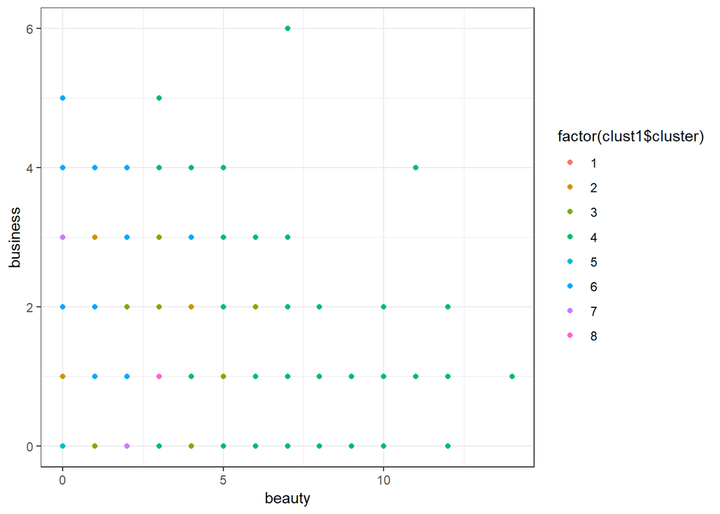

```r
# Run k-means with 8 clusters and 25 starts
set.seed(20)
clust1 = kmeans(X, 8, nstart=25)

library(data.table)
figure_cluster_dependence<-aggregate(X,by=list(clust1$cluster),FUN=mean)

check=apply(figure_cluster_dependence,2,function(x) which(x==max(x)))
check=data.table(colnames(socialmkt)[1:length(colnames(socialmkt))], check[1:length(check)])


########### Getting features in each cluster

Cluster_1=subset(check,check$V2==1)
Cluster_2=subset(check,check$V2==2)
Cluster_3=subset(check,check$V2==3)
Cluster_4=subset(check,check$V2==4)
Cluster_5=subset(check,check$V2==5)
Cluster_6=subset(check,check$V2==6)
Cluster_7=subset(check,check$V2==7)
Cluster_8=subset(check,check$V2==8)

########## Checking mean of each feature in cluster

# clust1$center[1,]*sigma + mu
# clust1$center[2,]*sigma + mu
# clust1$center[3,]*sigma + mu

library(ggplot2)
library(fpc)
qplot(beauty, business,data=socialmkt, color=factor(clust1$cluster))
```

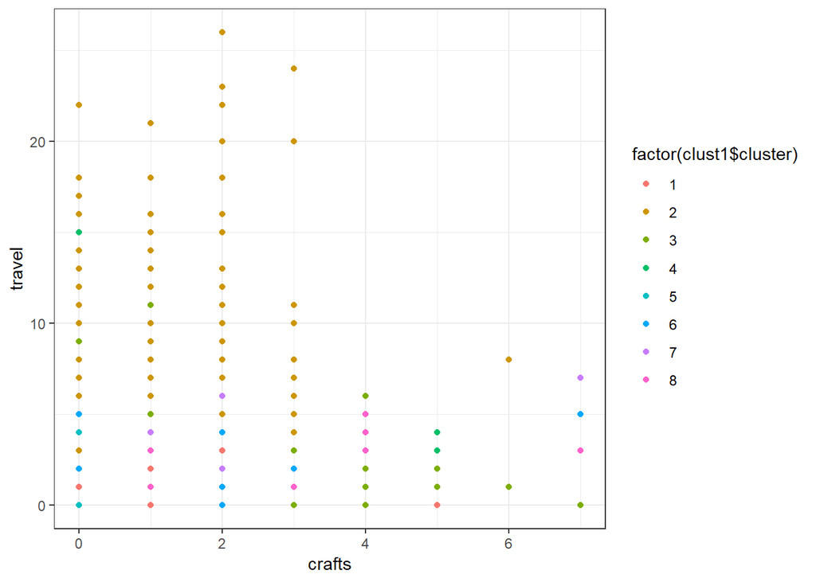

```r
qplot(crafts,travel, data=socialmkt, color=factor(clust1$cluster))
```

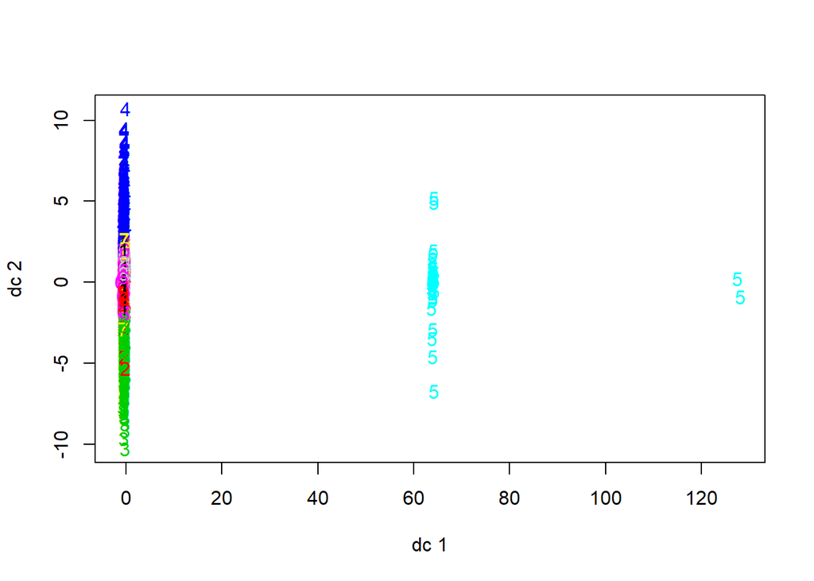

```r
plotcluster(X, clust1$cluster, col=as.factor(clust1$cluster))
```

```r
Cluster_1
```

```
## Empty data.table (0 rows) of 2 cols: V1,V2
```

```r
Cluster_2
```

```
##            V1 V2
## 1:     travel  2
## 2:   politics  2
## 3:       news  2
## 4:  computers  2
## 5: automotive  2
```

```r
Cluster_3
```

```
##               V1 V2
## 1: sports_fandom  3
## 2:          food  3
## 3:        family  3
## 4:        crafts  3
## 5:      religion  3
## 6:     parenting  3
## 7:        school  3
```

```r
Cluster_4
```

```
##               V1 V2
## 1: photo_sharing  4
## 2: uncategorized  4
## 3:         music  4
## 4:       cooking  4
## 5:        beauty  4
## 6:       fashion  4
```

```r
Cluster_5
```

```
##                 V1 V2
## 1: home_and_garden  5
## 2:            spam  5
## 3:           adult  5
```

```r
Cluster_6
```

```
##                V1 V2
## 1:        chatter  6
## 2: current_events  6
## 3:        tv_film  6
## 4:       shopping  6
## 5:       business  6
## 6:            art  6
## 7:         dating  6
## 8: small_business  6
```

```r
Cluster_7
```

```
##                V1 V2
## 1:  online_gaming  7
## 2:    college_uni  7
## 3: sports_playing  7
```

```r
Cluster_8
```

```
##                  V1 V2
## 1:                X  8
## 2: health_nutrition  8
## 3:              eco  8
## 4:         outdoors  8
## 5: personal_fitness  8
```

```r
#Can use the commands below to check clusters for the different followers

# which(clust1$cluster == 1)
# which(clust1$cluster == 2)
# which(clust1$cluster == 3)
```

Also tried hierarchical clustering :

```r
# Center/scale the data
socialmkt_scaled <- scale(socialmkt[,-1], center=TRUE, scale=TRUE)

# Distance matrix using the dist function (average distange between points)
socialmkt_distance_matrix = dist(socialmkt_scaled, method='euclidean')


#average linkage function
hier_socialmkt = hclust(socialmkt_distance_matrix, method='average')


#plot(hier_socialmkt, cex=0.8)   (Very complex dendogram)

#the y axis predicts the proximity between the points


# Cut the tree into 8 clusters

cluster1 = cutree(hier_socialmkt, k=8)

# Using single ("max"/"complete") linkage instead
hier_socialmkt2 = hclust(socialmkt_distance_matrix, method='complete')

# Plot the dendrogram
#plot(hier_socialmkt2, cex=0.8)     (too complex)
cluster2 = cutree(hier_socialmkt2, k=5)
summary(factor(cluster2))
```

```
##    1    2    3    4    5
##  626 7181   16   49   10
```

```r
# Using single ("min"/"single") linkage instead
hier_socialmkt3 = hclust(socialmkt_distance_matrix, method='single')

# Plot the dendrogram
# plot(hier_socialmkt3, cex=0.8)    (too complex)
cluster3 = cutree(hier_socialmkt3, k=5)
summary(factor(cluster3))
```

```
##    1    2    3    4    5
## 7831   47    2    1    1
```

```r
# Examine the cluster members

# which(cluster3 == 1)
# which(cluster3 == 2)
# which(cluster3 == 3)
```